# teste

```python
dados3.corr()
```

|  | index | deleted | created | total_users | churn |
| --- | --- | --- | --- | --- | --- |
| index | 1.000000 | 0.842707 | -0.335842 | 0.999464 | 0.629175 |
| deleted | 0.842707 | 1.000000 | -0.389902 | 0.829742 | 0.929532 |
| created | -0.335842 | -0.389902 | 1.000000 | -0.317045 | -0.319191 |
| total_users | 0.999464 | 0.829742 | -0.317045 | 1.000000 | 0.613276 |
| churn | 0.629175 | 0.929532 | -0.319191 | 0.613276 | 1.000000 |

### O churn tem uma relação bem maior com a quantidade de assinantes deletados do que com a de assinantes criados

```python
X = dados3.iloc[:, 0].values.reshape(-1, 1)
Y = dados3.iloc[:, 3].values.reshape(-1, 1)
linear_regressor = LinearRegression()
linear_regressor.fit(X, Y)
previsao = linear_regressor.predict(X)
linear_regressor.coef_
```

```
array([[-0.38844257]])
```

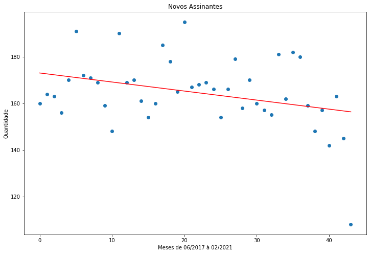

```python
plt.figure(figsize=(12, 8))
plt.scatter(X, Y)
plt.plot(X, previsao, color='#ff0009')
plt.title('Novos Assinantes')
plt.xlabel('Meses de 06/2017 à 02/2021')
plt.ylabel('Quantidade')
plt.show()
```

```python
X = dados3.iloc[:, 0].values.reshape(-1, 1)
Y = dados3.iloc[:, 2].values.reshape(-1, 1)
linear_regressor = LinearRegression()
linear_regressor.fit(X, Y)
previsao = linear_regressor.predict(X)
linear_regressor.coef_
```

```
array([[0.58040874]])
```

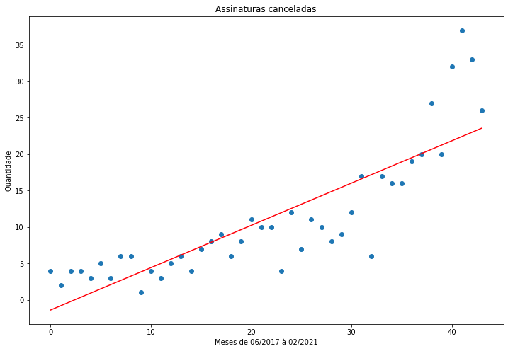

```python
plt.figure(figsize=(12, 8))
plt.scatter(X, Y)
plt.plot(X, previsao, color='#ff0009')
plt.title('Assinaturas canceladas')
plt.xlabel('Meses de 06/2017 à 02/2021')
plt.ylabel('Quantidade')
plt.show()
```

## Voltando para a analise do dataset inicial

```python
dados.corr()
```

|  | version | average_ticket | items_quantity | all_revenue | all_orders | recency | churn |
| --- | --- | --- | --- | --- | --- | --- | --- |
| version | 1.000000 | -0.002014 | -0.006876 | 0.020395 | 0.020270 | -0.009380 | 0.016267 |
| average_ticket | -0.002014 | 1.000000 | -0.006841 | 0.164848 | 0.004029 | 0.008219 | -0.005511 |
| items_quantity | -0.006876 | -0.006841 | 1.000000 | 0.004357 | 0.005265 | 0.011600 | -0.011259 |
| all_revenue | 0.020395 | 0.164848 | 0.004357 | 1.000000 | 0.981641 | -0.010756 | 0.034901 |
| all_orders | 0.020270 | 0.004029 | 0.005265 | 0.981641 | 1.000000 | -0.013639 | 0.037219 |
| recency | -0.009380 | 0.008219 | 0.011600 | -0.010756 | -0.013639 | 1.000000 | -0.805567 |
| churn | 0.016267 | -0.005511 | -0.011259 | 0.034901 | 0.037219 | -0.805567 | 1.000000 |

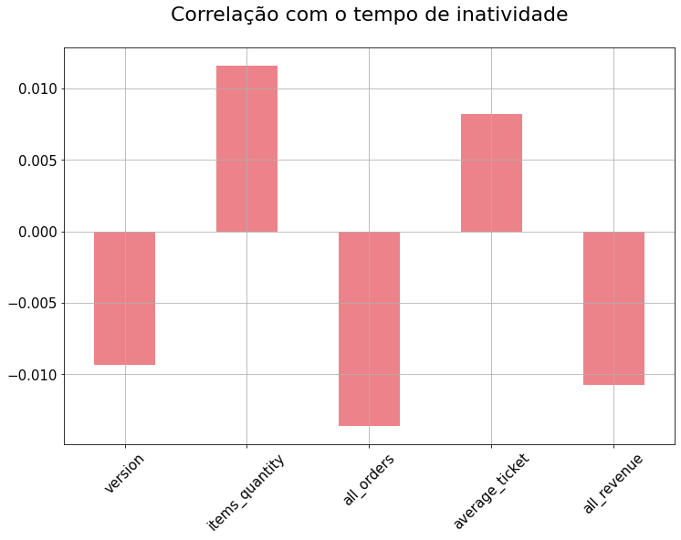

```python
selecao = dados[['status','version','items_quantity', 'all_orders', 'average_ticket', 'all_revenue']]
correlations = selecao.corrwith(dados.recency)
correlations = correlations[correlations!=1]
correlations.plot.bar(figsize = (12, 8),fontsize = 15, color = '#ec838a',rot = 45, grid = True)
plt.title('Correlação com o tempo de inatividade\n', horizontalalignment="center", fontstyle = "normal", fontsize = "22")
```

### Recency não apresenta nenhuma correlação significatica com nenhum outro dado além do churn

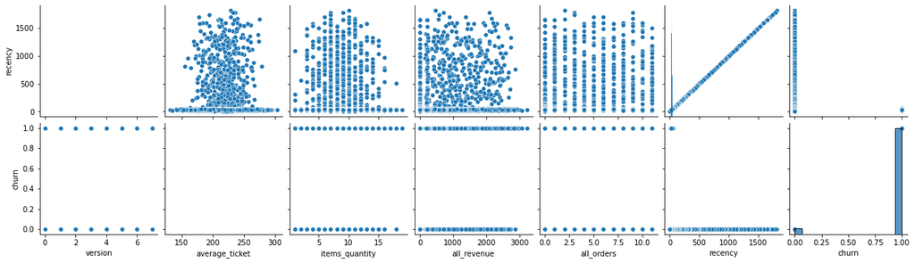

```python
sns.pairplot(dados, y_vars = ['recency','churn'])
```

```python
X = dados.iloc[:, 16].values.reshape(-1, 1)
Y = dados.iloc[:, 12].values.reshape(-1, 1)
linear_regressor = LinearRegression()
linear_regressor.fit(X, Y)
Ticket_medio_pred = linear_regressor.predict(X)
```

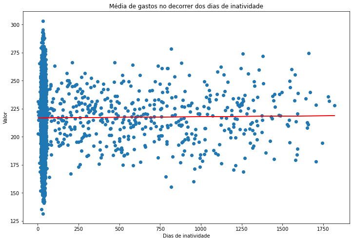

```python
plt.figure(figsize=(12, 8))
plt.scatter(X, Y)
plt.plot(X, Ticket_medio_pred, color='#ff0009')
plt.title('Média de gastos no decorrer dos dias de inatividade')
plt.xlabel('Dias de inatividade')
plt.ylabel('Valor')
plt.show()
```

```python
X = dados.iloc[:, 16].values.reshape(-1, 1)
Y = dados.iloc[:, 13].values.reshape(-1, 1)
linear_regressor = LinearRegression()
linear_regressor.fit(X, Y)
Ticket_medio_pred = linear_regressor.predict(X)
```

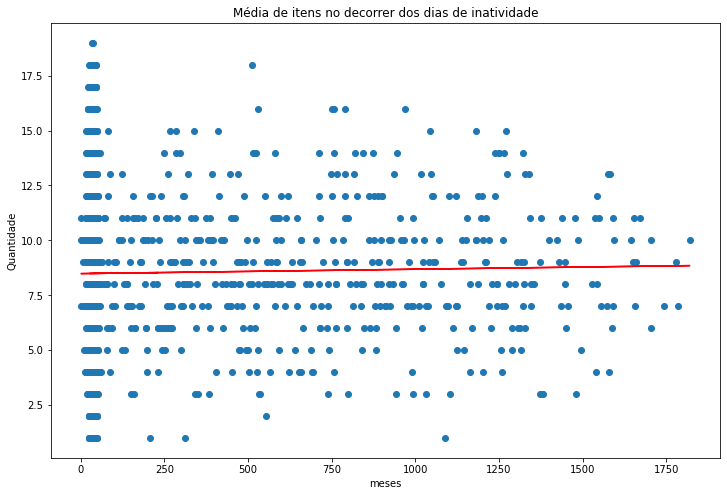

```python
plt.figure(figsize=(12, 8))
plt.scatter(X, Y)
plt.plot(X, Ticket_medio_pred, color='#ff0009')
plt.title('Média de itens no decorrer dos dias de inatividade')
plt.xlabel('meses')
plt.ylabel('Quantidade')
plt.show()
```

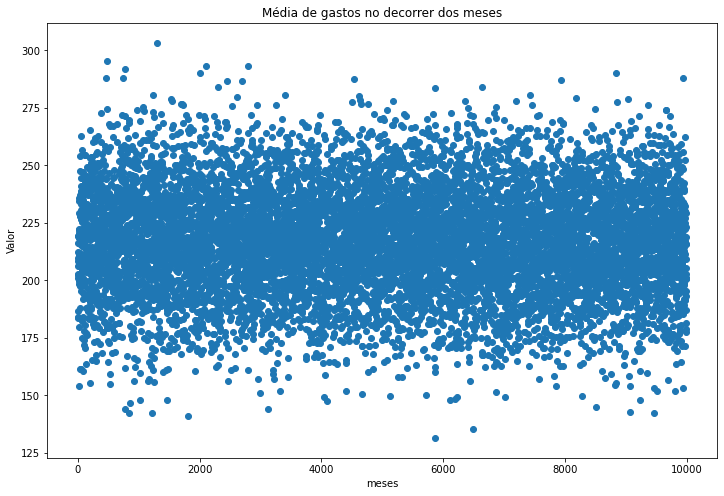

```python
plt.figure(figsize=(12, 8))
plt.scatter(dados.index, dados.average_ticket)
plt.title('Média de gastos no decorrer dos meses')
plt.xlabel('meses')
plt.ylabel('Valor')
plt.show()
```

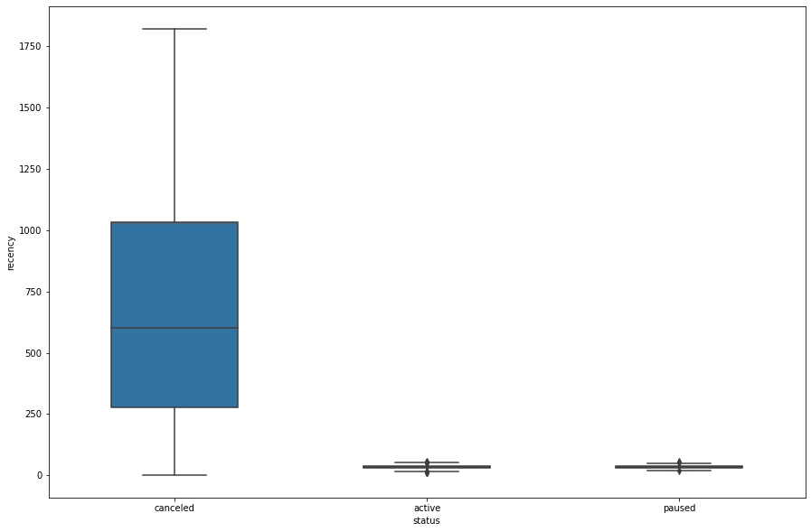

```python
sns.boxplot(data=dados, y = 'recency', x='status', width=0.5).figure.set_size_inches(15,10)
```

### Com a análise dos gráficos e correlações, observamos que o tempo de inatividade dos assinantes é o maior causador de churn

### A média de gastos não apresenta variacões significativas em relação ao tempo de inatividade indicando que os preços não são uma das causas do churn

## Próximos passos:

#### para diminuir o churn teremos que diminuir o tempo de inatividade dos clientes, logo os clientes terão que realizar compras então um bom caminho para isso seria oferecer descontos progressivos por volume e/ou frete gratis.